# Ekonometria przestrzenna

Patrycja Karpicka, Wiktoria Itych, Filip Bieszke, Michał Książek

# 1. Wprowadzenie do projektu

Tematem projektu jest estymacja przyczynowo-skutkowych modeli przestrzennych wyjaśniających kształtowanie się parytetu siły nabywczej (PPP) w 27 krajach Unii Europejskiej w latach 2013-2024. Dane zostały pobrane z Eurostatu. Dobór zmiennych oraz interpretacja ich wpływu opierają się na teoriach Balassy-Samuelsona (1964), koncepcjach konwergencji gospodarczej oraz wynikach badań zawartych m.in. w pracach Gelb i Diofasi (2016) oraz Taylor i Taylor (2004), a także w raportach OECD, IMF (International Monetary Fund) i KE (Komisja Europejska). Przeprowadzone testy oraz estymowane modele zostały opracowane w oparciu o materiały dydaktyczne z kursu Ekonometria przestrzenna autorstwa dr A. Kordalskiej, stanowiące podstawę metodyczną niniejszej analizy.

## Uzasadnienie wyboru zjawiska

Wybór parytetu siły nabywczej (PPP) jako zmiennej objaśnianej znajduje silne uzasadnienie zarówno w teorii ekonomicznej, jak i w praktyce analiz porównawczych. PPP stanowi jedno z najważniejszych narzędzi służących do realnej oceny poziomu życia, siły nabywczej pieniądza oraz stopnia rozwoju gospodarczego w ujęciu międzynarodowym. W odróżnieniu od nominalnych kursów walutowych, które podlegają wpływom spekulacyjnym, politycznym i cyklicznym, PPP opiera się na faktycznym koszcie zakupu identycznego koszyka dóbr i usług w różnych krajach, co czyni go bardziej stabilnym i reprezentatywnym wskaźnikiem realnych różnic ekonomicznych.

Ujęcie PPP jako zmiennej zależnej umożliwia analizę głębszych mechanizmów kształtujących poziom cen względnych pomiędzy państwami – mechanizmów, które często nie są dostrzegalne w ramach standardowych wskaźników makroekonomicznych. Dzięki temu możliwe staje się uchwycenie złożonych zależności między czynnikami takimi jak poziom dochodów, koszty pracy, presja inflacyjna czy struktura demograficzno-przestrzenna a realną wartością pieniądza. Co więcej, PPP odgrywa coraz większą rolę w kontekście integracji gospodarczej i polityki spójności Unii Europejskiej, gdzie pełni funkcję korekcyjną w alokacji funduszy i ocenie poziomu konwergencji.

Z tych względów PPP nie tylko nadaje się do badań empirycznych jako zmienna objaśniana, ale wręcz staje się nośnikiem odpowiedzi na pytania o to, jak fundamentalne cechy gospodarek wpływają na realną siłę nabywczą ich obywateli. W dobie globalizacji i regionalnej integracji ekonomicznej zrozumienie determinantów PPP pozwala na bardziej precyzyjną diagnozę różnic rozwojowych oraz na formułowanie rekomendacji politycznych sprzyjających równoważeniu tych różnic.

## Uzasadnienie wyboru zmiennych objaśniających

Parytet siły nabywczej (Purchasing Power Parity, PPP) jest kluczową kategorią w porównaniach międzynarodowych, służącą do oceny realnej siły nabywczej walut i poziomu życia w poszczególnych krajach. W literaturze ekonomicznej wskazuje się na szereg czynników makroekonomicznych i strukturalnych, które wpływają na poziom PPP. Wśród nich na szczególną uwagę zasługują: produkt krajowy brutto (PKB) per capita, średnie wynagrodzenia, stopa bezrobocia, jednostkowy koszt pracy, inflacja, ceny energii elektrycznej, gęstość zaludnienia oraz długość członkostwa w Unii Europejskiej.

Poziom PKB per capita w ujęciu realnym i skorygowanym o PPP jest klasycznym wyznacznikiem poziomu rozwoju gospodarczego kraju i odzwierciedla jego produktywność. W kontekście teorii Balassy-Samuelsona wyższa produktywność w sektorach tradable w krajach wysoko rozwiniętych prowadzi do wzrostu wynagrodzeń w całej gospodarce, co z kolei podnosi ceny w sektorach non-tradable i skutkuje wyższym ogólnym poziomem cen, a tym samym wyższym PPP (Balassa, 1964; Samuelson, 1964; Taylor & Taylor, 2004).

Średnie wynagrodzenia są ściśle powiązane z poziomem PKB per capita i stanowią istotny czynnik kształtujący siłę nabywczą ludności. Wyższe zarobki umożliwiają większą konsumpcję, ale jednocześnie wpływają na wzrost kosztów produkcji i cen towarów i usług, co bezpośrednio wpływa na relatywny poziom cen i PPP (OECD, 2023).

Stopa bezrobocia oddziałuje na PPP głównie poprzez mechanizmy podaży i popytu na rynku pracy. Wysokie bezrobocie może prowadzić do obniżenia płac i ograniczenia popytu konsumpcyjnego, co w dłuższym okresie może wywierać presję deflacyjną i wpływać na poziom cen, a tym samym zmieniać wartość PPP (IMF, 2020). Dodatkowo, kraje o trwałym bezrobociu strukturalnym mogą wykazywać niższy poziom cen względnych, co sztucznie zawyża ich PPP.

Jednostkowy koszt pracy (Unit Labour Cost, ULC) jest ważnym wskaźnikiem konkurencyjności kosztowej gospodarki. Wyższy ULC oznacza, że produkcja dóbr i usług staje się relatywnie droższa, co przekłada się na wzrost ogólnego poziomu cen. W efekcie PPP rośnie, gdyż koszyk dóbr w danym kraju staje się relatywnie droższy w porównaniu z innymi gospodarkami (European Commission, 2023).

Inflacja, będąca miarą tempa wzrostu cen, jest jednym z kluczowych mechanizmów korekcyjnych w teorii relatywnego PPP. Zgodnie z tą teorią, różnice w inflacji między krajami powinny prowadzić do proporcjonalnych zmian w nominalnym kursie walutowym, tak aby utrzymać stały poziom siły nabywczej (Taylor & Taylor, 2004). W praktyce oznacza to, że kraje o wyższej inflacji powinny wykazywać wyższy PPP, jeśli kurs nominalny nie dostosowuje się natychmiast.

Ceny energii elektrycznej są ważnym składnikiem kosztów produkcji i konsumpcji w gospodarce. Znaczące różnice w kosztach energii między państwami członkowskimi UE wpływają na ogólny poziom cen konsumpcyjnych, zwłaszcza w sektorach energochłonnych. Wyższe ceny energii podnoszą koszty życia i produkcji, co przekłada się na wzrost PPP (Eurostat, 2023).

Gęstość zaludnienia może pośrednio wpływać na PPP poprzez presję cenową w obszarach zurbanizowanych. Regiony o wysokiej gęstości zaludnienia zazwyczaj cechują się wyższymi kosztami utrzymania, szczególnie w sektorach takich jak mieszkalnictwo czy transport, co wpływa na lokalne poziomy cen i może rzutować na skorygowane PPP w analizach subnarodowych.(Brueckner, 2000)

Wreszcie, czas członkostwa w Unii Europejskiej jest czynnikiem instytucjonalnym, który może wpływać na PPP poprzez procesy konwergencji gospodarczej, spadek barier handlowych oraz integrację rynków pracy i kapitału. Badania empiryczne wskazują, że dłuższe członkostwo w UE sprzyja zbliżaniu się poziomów cen i wynagrodzeń do średniej unijnej, co prowadzi do relatywnego wzrostu PPP w krajach peryferyjnych (European Commission, 2023).

# 2. Rozpoczęcie pracy w R studio

## Wykresy zmiennych

Poniższe wykresy przedstawiają zależność pomiędzy PPP a poszczególnymi zmiennymi.

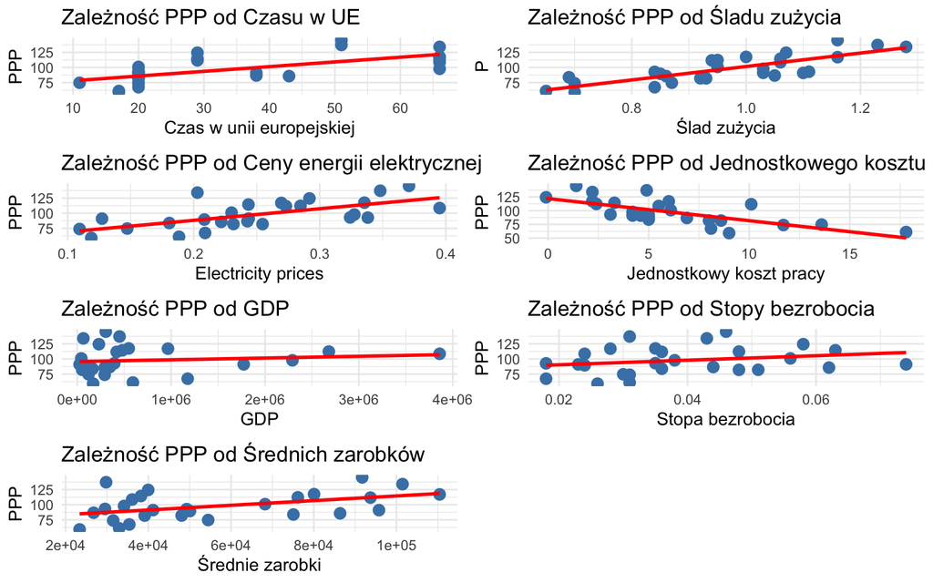

## Macierz korelacji

Macierz korelacji wskazuje, że parytet siły nabywczej (PPP) jest silnie dodatnio skorelowany ze śladem zużycia CO₂ (0,81), długością członkostwa w Unii Europejskiej (0,67) oraz cenami energii elektrycznej (0,65), co świadczy o powiązaniu siły nabywczej z poziomem rozwoju i konsumpcji. Umiarkowanie dodatnie korelacje obserwuje się w przypadku średnich zarobków (0,46), stopy bezrobocia (0,24) oraz PKB (0,12). Z kolei jednostkowy koszt pracy (–0,70) i inflacja (–0,45) wykazują wyraźnie negatywny związek z PPP, co wskazuje ich ograniczający wpływ na realną siłę nabywczą.

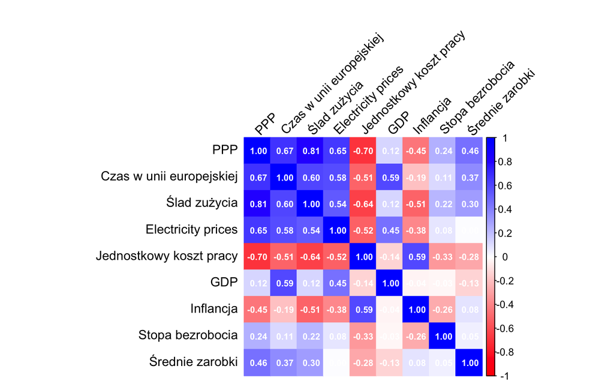

[output not shown]

[output cut: 519 more lines]

[output not shown]

## Badanie zmiennej objaśnianej pod kątem istnienia zależności

## Statystyka Morana I

Test Morana I jest statystyką badającą przestrzenne zależności globalne. Globalna zależność przestrzenna (globalne grupowanie się danych) wynika z występowania zależności przestrzennej PPP w obrębie całego badanego obszaru, czyli krajów UE27. Hipoteza zerowa mówi, że występuje brak powiązań przestrzennych, to znaczy wartości PPP są losowo rozmieszczone pomiędzy krajami. Natomiast hipoteza alternatywna mówi, że występują powiązania przestrzenne. Na podstawie otrzymanego p-value 2,2*10^(-16), mniejszego od poziomu istotności wynoszącego 0,05, należy odrzucić hipotezę zerową na rzecz alternatywnej. Wartość statystyki Morana I równa 0,76 oznacza, że występuje bardzo silna dodatnia autokorelacja przestrzenna zmiennej PPP między krajami UE27. Kraje sąsiadujące ze sobą mają zbliżony poziom PPP. Innymi słowy: PPP nie jest przestrzennie losowe, lecz wykazuje przestrzenną strukturę klastra. Modelowanie przestrzenne (SAR, SEM) jest wskazane.

```
##
##  Moran I test under randomisation
##
## data:  eu27_merged$PPP
## weights: weights_list
##
## Moran I statistic standard deviate = 56.261, p-value < 2.2e-16
## alternative hypothesis: greater
## sample estimates:
## Moran I statistic       Expectation          Variance
##      0.7586817328     -0.0030959752      0.0001833332
```

Wizualnym potwierdzeniem powyższych wniosków jest wykres rozproszenia Morana, który przedstawia zależność autoregresyjną – relację standaryzowanej wartości PPPw danej lokalizacji do standaryzowanej wartości PPP w innych lokalizacjach (lagged eu27_merged$PPP). Większość obserwacji skupia się w pierwszej (High-High) i trzeciej (Low-Low) ćwiartce wykresu, co wskazuje na obecność dodatnich klastrów – regiony o wysokim PPP otoczone są przez inne regiony o wysokim PPP, a regiony o niskim PPP sąsiadują z podobnie słabymi gospodarczo obszarami. Obserwacje znajdujące się w drugiej (Low-High) i czwartej (High-Low) ćwiartce mogą być traktowane jako przestrzenne outliery – odstępstwa od lokalnego kontekstu.

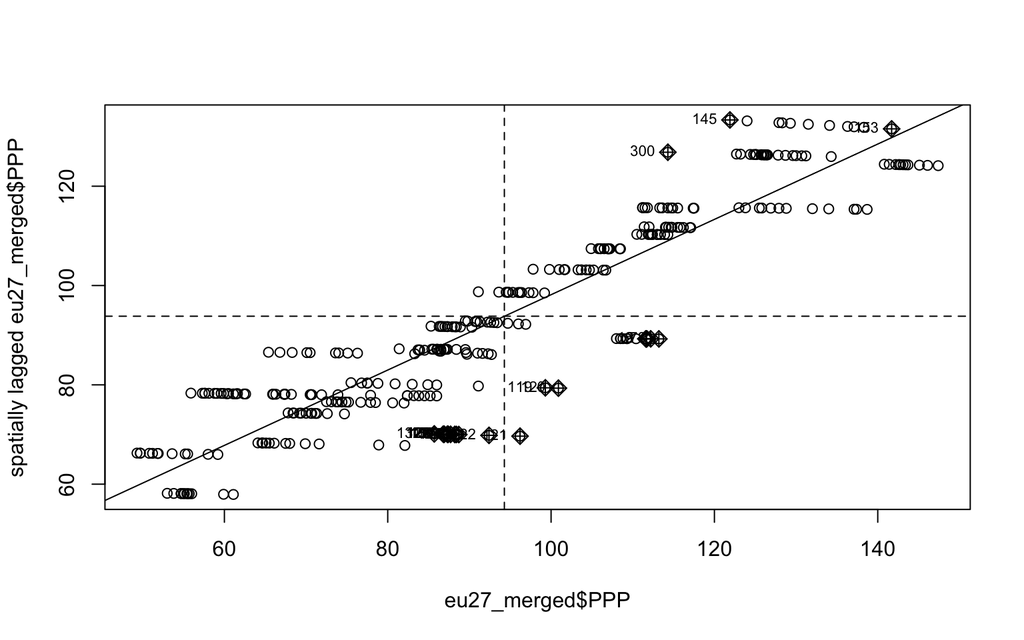

[output not shown]

[output cut: 56 more lines]

[output not shown]

## Mapa klastrów

Wyniki lokalnych wskaźników autokorelacji przestrzennej (LISA) zostały zobrazowane na mapie klastra LISA, przedstawiającej rozmieszczenie czterech typów przestrzennych powiązań dla siły nabywczej (PPP) w krajach UE. Klasyfikacja uwzględnia zarówno wartość PPP danego kraju, jak i wartość PPP jego sąsiadów, dzieląc obserwacje na istotne klastry: High-High, Low-Low, High-Low oraz przypadki nieistotne statystycznie.

Kolorem pomarańczowym oznaczono kraje o wysokim PPP otoczone przez inne kraje również o wysokim PPP (high-high). Zidentyfikowano szeroki pas takich krajów w Europie Zachodniej i Północnej, m.in. Niemcy, Belgia, Holandia, Irlandia, Francja, Włochy oraz państwa skandynawskie, czyli Szwecja i Finlandia. Wskazuje to na obecność regionalnych „klastrów dobrobytu” – zgrupowań przestrzennych krajów o wysokiej sile nabywczej.

Kolorem niebieskim oznaczono obszary o niskim PPP otoczone przez kraje o podobnie niskim poziomie siły nabywczej (low-low). Taki wzorzec zaobserwowano głównie w Europie Środkowo-Wschodniej, obejmując m.in. Litwę, Łotwę, Polskę, Czechy, Słowację, Węgry, Rumunię, Bułgarię, Grecję i Chorwację. Sugeruje to istnienie trwałych przestrzennych obszarów o relatywnie niższym poziomie życia.

Kolorem czerwonym oznaczono obszary o wysokim PPP otoczone przez sąsiadów o niskim PPP (high-low). Taki przypadek wystąpił np. w Austrii czy Estonii, co może świadczyć o ich wyjątkowo dobrej sytuacji ekonomicznej względem najbliższego otoczenia. Są to obserwacje odstające od lokalnego trendu.

Kraje oznaczone kolorem zielonym, takie jak Portugalia, Hiszpania czy Cypr, zostały sklasyfikowane jako statystycznie nieistotne pod względem lokalnej autokorelacji przestrzennej. Ich poziom PPP nie wykazuje jednoznacznego przestrzennego wzorca względem sąsiadów.

[output not shown]

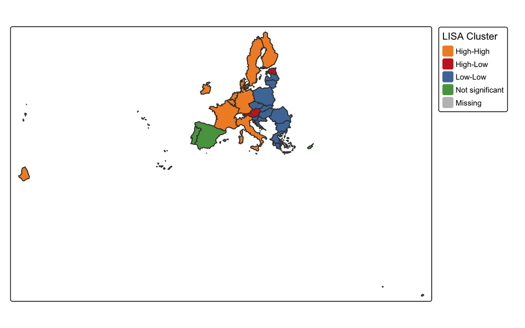

## Mapa istotności Mapa istotności LISA prezentuje przestrzenny rozkład wyników lokalnych testów Morana I dla zmiennej PPP w krajach UE, przy założonym poziomie istotności α = 0,05. Na mapie kolorem czerwonym oznaczono kraje, dla których lokalna autokorelacja przestrzenna została uznana za istotną statystycznie (p ≤ 0,05). Są to regiony, w których wartość PPP pozostaje w silnym związku z wartością PPP w krajach sąsiednich – zarówno dodatnim (klastry High-High i Low-Low), jak i ujemnym (High-Low i Low-High). Kolorem białym oznaczono obszary, w których takiej istotności nie stwierdzono – zmienność PPP w tych krajach nie wykazuje wyraźnych wzorców przestrzennych względem najbliższego otoczenia.

Z analizy wynika, że większość krajów UE charakteryzuje się istotną lokalną autokorelacją przestrzenną PPP, co stanowi silne potwierdzenie przestrzennego uwarunkowania siły nabywczej w regionie. Jedynie Portugalia, Hiszpania i Cypr nie wykazują istotnej lokalnej zależności przestrzennej parytety siły nabywczej.

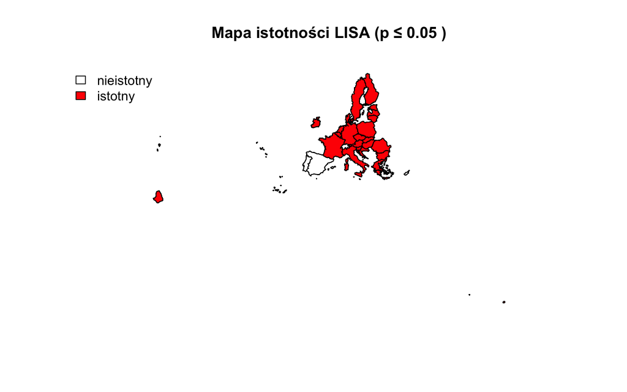

# 3. Budowanie modeli przyczynowo-skutkowych

Wraz z rozpoczęciem modelowania zdecydowano się na usunięcie zmiennych objaśniających inflacja i stopa bezrobocia, ponieważ zaniżały one wyniki modeli panelowych. Istotność statystyczna pozostałych zmiennych objaśniających była na niższym poziomie oraz podwyższały one p-value lambdy.

### Model podstawowy OLS (bez interakcji)

W ramach przeprowadzonej analizy oszacowano model regresji liniowej mający na celu wyjaśnienie zmienności siły nabywczej (PPP) w krajach Unii Europejskiej na podstawie wybranych zmiennych społeczno-ekonomicznych. Model uwzględniał takie czynniki jak: ceny energii elektrycznej, logarytm produktu krajowego brutto (PKB), jednostkowy koszt pracy, średnie wynagrodzenia, gęstość zaludnienia, ślad zużycia oraz czas członkostwa w Unii Europejskiej.

Model charakteryzuje się bardzo wysokim współczynnikiem determinacji – wartość R² wynosi 0,8153, a skorygowany R² to 0,8112. Oznacza to, że ponad 81% zmienności PPP w krajach UE można wyjaśnić na podstawie przyjętych w modelu zmiennych objaśniających. Statystyka F równa 199,3 oraz p-wartość < 2,2e-16 wskazują, że model jako całość jest istotny statystycznie, co potwierdza przydatność zastosowanych zmiennych w wyjaśnianiu badanego zjawiska.

Wyniki regresji pokazują, że większość zmiennych istotnie wpływa na siłę nabywczą. Wyższe ceny energii elektrycznej i logarytm PKB mają dodatni wpływ na PPP, co odzwierciedla rozwój gospodarczy. Jednostkowy koszt pracy działa negatywnie, obniżając PPP przez spadek konkurencyjności. Średnie zarobki silnie podnoszą siłę nabywczą. Gęstość zaludnienia ma negatywny wpływ, sugerując wyższe koszty życia w bardziej zatłoczonych regionach. Dodatnia zależność śladu zużycia CO2 z PPP potwierdza związek dobrobytu z większym zużyciem. Czas członkostwa w UE okazał się nieistotny statystycznie, co wskazuje, że sam fakt długości przynależności nie wpływa bezpośrednio na siłę nabywczą po uwzględnieniu innych czynników.

```r
# Model klasyczny OLS
ols_model <- lm(PPP ~ `Electricity prices` + log(GDP) + `Jednostkowy koszt pracy` + `Średnie zarobki` +
`Gęstość zaludnienia` + `Ślad zużycia` + `Czas w unii europejskiej`, data = eu27_merged)
summary(ols_model)
```

```
##
## Call:
## lm(formula = PPP ~ `Electricity prices` + log(GDP) + `Jednostkowy koszt pracy` +
##     `Średnie zarobki` + `Gęstość zaludnienia` + `Ślad zużycia` +
##     `Czas w unii europejskiej`, data = eu27_merged)
##
## Residuals:
##      Min       1Q   Median       3Q      Max
## -27.7763  -7.6320  -0.0347   6.9080  26.5844
##
## Coefficients:
##                              Estimate Std. Error t value Pr(>|t|)
## (Intercept)                -4.712e+01  1.102e+01  -4.275 2.53e-05 ***
## `Electricity prices`        4.911e+01  1.225e+01   4.008 7.65e-05 ***
## log(GDP)                    3.135e+00  7.370e-01   4.253 2.78e-05 ***
## `Jednostkowy koszt pracy`  -5.655e-01  1.539e-01  -3.674 0.000281 ***
## `Średnie zarobki`           2.069e-04  3.008e-05   6.880 3.22e-11 ***
## `Gęstość zaludnienia`      -1.056e-02  2.441e-03  -4.327 2.03e-05 ***
## `Ślad zużycia`              8.965e+01  5.144e+00  17.428  < 2e-16 ***
## `Czas w unii europejskiej`  4.644e-02  6.315e-02   0.735 0.462661
## ---
## Signif. codes:  0 '***' 0.001 '**' 0.01 '*' 0.05 '.' 0.1 ' ' 1
##
## Residual standard error: 10.88 on 316 degrees of freedom
## Multiple R-squared:  0.8153, Adjusted R-squared:  0.8112
## F-statistic: 199.3 on 7 and 316 DF,  p-value: < 2.2e-16
```

### Testy statystyczne modelu OLS

Przeprowadzone testy diagnostyczne dla modelu OLS wskazują na istotne odstępstwa od klasycznych założeń modelu liniowego. Zarówno test Breuscha-Pagana (p < 2,2e-16), jak i test White’a (p = 4e-06) wykazują istotną heteroskedastyczność, co oznacza, że wariancja składnika losowego nie jest stała i może zależeć od poziomu zmiennych objaśniających. Test Durbina-Watsona (DW = 0,30676, p < 2,2e-16) jednoznacznie wskazuje na silną dodatnią autokorelację składnika losowego, co stanowi istotne naruszenie założeń klasycznego modelu regresji. Z kolei testy normalności – Jarque’a-Bery (p = 0,2906) oraz Shapiro-Wilka (p = 0,1013) – nie dają podstaw do odrzucenia hipotezy o normalnym rozkładzie reszt. Oznacza to, że mimo występowania heteroskedastyczności i autokorelacji, rozkład reszt można uznać za zgodny z normalnością, co umożliwia dalsze wnioskowanie przy zastosowaniu odpowiednich korekt estymatora. Kryterium AIC modelu OLS wynosi 2476,28.

```r
#weryfikacja modelu
ols_resid <- residuals(ols_model)
AIC(ols_model)
```

```
## [1] 2476.281
```

```r
#Breusch-Pagan - heteroskedastyczność
bptest(ols_model, studentize=FALSE)
```

```
##
##  Breusch-Pagan test
##
## data:  ols_model
## BP = 100.03, df = 7, p-value < 2.2e-16
```

```r
#White - heteroskedastyczność
white_test(ols_model)
```

```
## White's test results
##
## Null hypothesis: Homoskedasticity of the residuals
## Alternative hypothesis: Heteroskedasticity of the residuals
## Test Statistic: 24.67
## P-value: 4e-06
```

```r
#Durbin-Watson
dwtest(ols_model)
```

```
##
##  Durbin-Watson test
##
## data:  ols_model
## DW = 0.30676, p-value < 2.2e-16
## alternative hypothesis: true autocorrelation is greater than 0
```

```r
#Jarque-Bera - normalność reszt
jarque.bera.test(ols_resid)
```

```
##
##  Jarque Bera Test
##
## data:  ols_resid
## X-squared = 2.4715, df = 2, p-value = 0.2906
```

```r
#Shapiro-Wilk - normalność
shapiro.test(ols_resid)
```

```
##
##  Shapiro-Wilk normality test
##
## data:  ols_resid
## W = 0.99247, p-value = 0.1013
```

W celu oceny poprawności klasycznego modelu regresji OLS dla siły nabywczej (PPP) przeprowadzono również test Morana I na resztach. Wynik (I = 0,4523; p < 2,2e–16) wskazuje na silną dodatnią autokorelację przestrzenną. Innymi słowy, w modelu występuje systematyczna zależność przestrzenna w błędach, która została pominięta przy estymacji. Oznacza to naruszenie jednego z podstawowych założeń klasycznego modelu regresji – niezależności składnika losowego. Skutkiem jest nieefektywność estymatora OLS i ryzyko błędnych wniosków statystycznych.

Ponadto, mnożnik Lagrange’a jednoznacznie wskazuje na silną obecność zależności przestrzennych w modelu OLS wyjaśniającym zmienną PPP. Zarówno testy podstawowe (RSerr, RSlag), jak i ich wersje skorygowane (adjRSerr, adjRSlag), a także test łączony (SARMA), są istotne statystycznie na poziomie p < 0.001. Oznacza to, że w danych występują istotne efekty przestrzenne zarówno w składniku losowym, jak i w strukturze zależności między obserwacjami. Wyniki te sugerują, że model klasyczny jest nieadekwatny i powinien zostać zastąpiony przez model przestrzenny, np. SAR, SEM lub SARMA.

```r
# testy ex-ante
# test Morana dla reszt
moran.test(ols_resid, weights_list, zero.policy = TRUE)
```

```
##
##  Moran I test under randomisation
##
## data:  ols_resid
## weights: weights_list
##
## Moran I statistic standard deviate = 33.66, p-value < 2.2e-16
## alternative hypothesis: greater
## sample estimates:
## Moran I statistic       Expectation          Variance
##      0.4522603075     -0.0030959752      0.0001830084
```

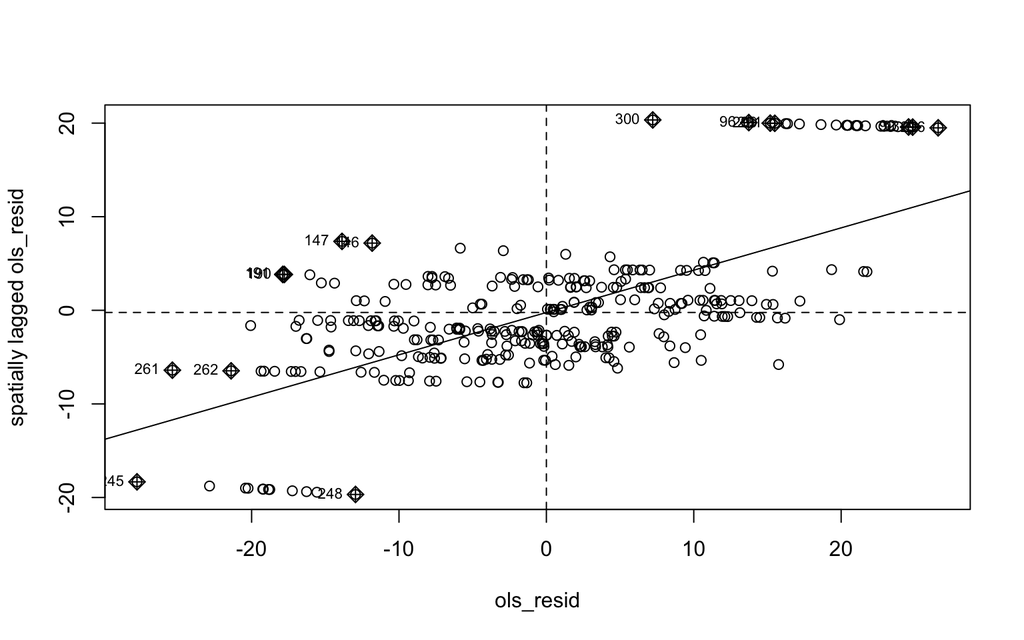

```r
moran.plot(ols_resid, weights_list, zero.policy = TRUE)
```

```r
# test Lagrange
lm.RStests(ols_model, listw=weights_list, test="all")
```

```
##
##  Rao's score (a.k.a Lagrange multiplier) diagnostics for spatial
##  dependence
##
## data:
## model: lm(formula = PPP ~ `Electricity prices` + log(GDP) +
## `Jednostkowy koszt pracy` + `Średnie zarobki` + `Gęstość zaludnienia` +
## `Ślad zużycia` + `Czas w unii europejskiej`, data = eu27_merged)
## test weights: weights_list
##
## RSerr = 1008.6, df = 1, p-value < 2.2e-16
##
##
##  Rao's score (a.k.a Lagrange multiplier) diagnostics for spatial
##  dependence
##
## data:
## model: lm(formula = PPP ~ `Electricity prices` + log(GDP) +
## `Jednostkowy koszt pracy` + `Średnie zarobki` + `Gęstość zaludnienia` +
## `Ślad zużycia` + `Czas w unii europejskiej`, data = eu27_merged)
## test weights: weights_list
##
## RSlag = 256.43, df = 1, p-value < 2.2e-16
##
##
##  Rao's score (a.k.a Lagrange multiplier) diagnostics for spatial
##  dependence
##
## data:
## model: lm(formula = PPP ~ `Electricity prices` + log(GDP) +
## `Jednostkowy koszt pracy` + `Średnie zarobki` + `Gęstość zaludnienia` +
## `Ślad zużycia` + `Czas w unii europejskiej`, data = eu27_merged)
## test weights: weights_list
##
## adjRSerr = 781.21, df = 1, p-value < 2.2e-16
##
##
##  Rao's score (a.k.a Lagrange multiplier) diagnostics for spatial
##  dependence
##
## data:
## model: lm(formula = PPP ~ `Electricity prices` + log(GDP) +
## `Jednostkowy koszt pracy` + `Średnie zarobki` + `Gęstość zaludnienia` +
## `Ślad zużycia` + `Czas w unii europejskiej`, data = eu27_merged)
## test weights: weights_list
##
## adjRSlag = 29.017, df = 1, p-value = 7.173e-08
##
##
##  Rao's score (a.k.a Lagrange multiplier) diagnostics for spatial
##  dependence
##
## data:
## model: lm(formula = PPP ~ `Electricity prices` + log(GDP) +
## `Jednostkowy koszt pracy` + `Średnie zarobki` + `Gęstość zaludnienia` +
## `Ślad zużycia` + `Czas w unii europejskiej`, data = eu27_merged)
## test weights: weights_list
##
## SARMA = 1037.6, df = 2, p-value < 2.2e-16
```

```r
testy_ex_ante <- lm.RStests(ols_model, listw=weights_list, test=c("LMerr","RLMerr","LMlag","RLMlag","SARMA"))
summary(testy_ex_ante)
```

```
##  Rao's score (a.k.a Lagrange multiplier) diagnostics for spatial
##  dependence
## data:
## model: lm(formula = PPP ~ `Electricity prices` + log(GDP) +
## `Jednostkowy koszt pracy` + `Średnie zarobki` + `Gęstość zaludnienia` +
## `Ślad zużycia` + `Czas w unii europejskiej`, data = eu27_merged)
## test weights: weights_list
##
##          statistic parameter   p.value
## RSerr     1008.622         1 < 2.2e-16 ***
## adjRSerr   781.209         1 < 2.2e-16 ***
## RSlag      256.430         1 < 2.2e-16 ***
## adjRSlag    29.017         1 7.173e-08 ***
## SARMA     1037.639         2 < 2.2e-16 ***
## ---
## Signif. codes:  0 '***' 0.001 '**' 0.01 '*' 0.05 '.' 0.1 ' ' 1
```

## Model SAR

```r
# Oszacuj modele panelowe przestrzenne z macierzą euklidesową (SAR)
sar_model <- spml(
  PPP ~ Electricity.prices + log(GDP) + Jednostkowy.koszt.pracy +
        Średnie.zarobki + Gęstość.zaludnienia + Ślad.zużycia +
        Czas.w.unii.europejskiej,
  data = panel,
  listw = lw_ek,
  model = "within",
  effect = "individual",
  lag = TRUE,
  spatial.error = "none"
)

# log-likelihood z obiektu modelu
logL_SAR <- sar_model$logLik

# liczba parametrów – wszystkie współczynniki + rho (jeśli spatial lag)
k_SAR <- length(coef(sar_model)) + ifelse(!is.null(sar_model$rho), 1, 0)

# ręcznie obliczone AIC
AIC_SAR <- -2 * logL_SAR + 2 * k_SAR
AIC_SAR
```

```
## [1] 1683.004
```

```r
summary(sar_model)
```

```
## Spatial panel fixed effects lag model
##
##
## Call:
## spml(formula = PPP ~ Electricity.prices + log(GDP) + Jednostkowy.koszt.pracy +
##     Średnie.zarobki + Gęstość.zaludnienia + Ślad.zużycia +
##     Czas.w.unii.europejskiej, data = panel, listw = lw_ek, model = "within",
##     effect = "individual", lag = TRUE, spatial.error = "none")
##
## Residuals:
##      Min.   1st Qu.    Median   3rd Qu.      Max.
## -15.17308  -1.60630  -0.07217   1.39545  12.40331
##
## Spatial autoregressive coefficient:
##         Estimate Std. Error t-value Pr(>|t|)
## lambda -0.112509   0.099249 -1.1336    0.257
##
## Coefficients:
##                             Estimate  Std. Error t-value  Pr(>|t|)
## Electricity.prices        1.6168e+01  5.5770e+00  2.8991 0.0037427 **
## log(GDP)                  1.4328e+01  2.7872e+00  5.1407 2.738e-07 ***
## Jednostkowy.koszt.pracy   2.3522e-02  6.1325e-02  0.3836 0.7013015
## Średnie.zarobki          -1.8028e-04  4.6989e-05 -3.8367 0.0001247 ***
## Gęstość.zaludnienia       3.8926e-03  6.9554e-03  0.5596 0.5757225
## Ślad.zużycia             -2.7024e+00  4.3138e+00 -0.6265 0.5310066
## Czas.w.unii.europejskiej  1.0247e-01  1.5475e-01  0.6622 0.5078675
## ---
## Signif. codes:  0 '***' 0.001 '**' 0.01 '*' 0.05 '.' 0.1 ' ' 1
```

## Model SEM

Model SEM (Spatial Error Model) z efektami stałymi dla jednostek przestrzennych został oszacowany w celu uwzględnienia potencjalnej autokorelacji przestrzennej w składniku losowym. Współczynnik błędu przestrzennego (rho = –0,056) okazał się nieistotny statystycznie (p = 0,583), co sugeruje brak przestrzennej autokorelacji reszt, a tym samym ograniczoną zasadność zastosowania modelu błędu przestrzennego w analizowanym przypadku. Spośród zmiennych objaśniających istotny pozytywny wpływ na poziom parytetu siły nabywczej (PPP) wykazują ceny energii elektrycznej (p = 0,0044) oraz logarytm PKB (p < 0,001), natomiast średnie zarobki są istotne statystycznie, ale ich wpływ ma charakter negatywny (p < 0,001). Oznacza to, że wyższe ceny energii oraz większy rozmiar gospodarki sprzyjają wyższej sile nabywczej, natomiast wzrost przeciętnych zarobków – po uwzględnieniu innych czynników – może wiązać się z jej spadkiem, co może wskazywać na pośredni wpływ kosztów utrzymania. Pozostałe zmienne, takie jak jednostkowy koszt pracy, gęstość zaludnienia, ślad zużycia oraz czas członkostwa w UE, nie wykazały istotności statystycznej. Wartość kryterium informacyjnego Akaike’a (AIC = 2637,475) wskazuje na słabsze dopasowanie tego modelu w porównaniu do modelu SAR (AIC = 1683,004), co przemawia na korzyść wykorzystania modelu z opóźnieniem przestrzennym zmiennej zależnej w analizie danych.

```r
# SEM – przestrzenne zależności w błędach
sem_model <- spml((PPP) ~ Electricity.prices + log(GDP) + Jednostkowy.koszt.pracy + Średnie.zarobki + Gęstość.zaludnienia + Ślad.zużycia + Czas.w.unii.europejskiej,
                     data = panel, listw = lw_ek,
                     model = "within", effect = "individual",
                     lag = FALSE, spatial.error = "b")

# log-likelihood z obiektu modelu
logL_SEM <- sem_model$logLik

# liczba parametrów – wszystkie współczynniki + rho (jeśli spatial lag)
k_SEM <- length(coef(sem_model)) + ifelse(!is.null(sem_model$rho), 1, 0)

# ręcznie obliczone AIC
AIC_SEM <- -2 * logL_SEM + 2 * k_SEM
AIC_SEM
```

```
##          [,1]
## [1,] 2637.475
```

```r
summary(sem_model)
```

```
## Spatial panel fixed effects error model
##
##
## Call:
## spml(formula = (PPP) ~ Electricity.prices + log(GDP) + Jednostkowy.koszt.pracy +
##     Średnie.zarobki + Gęstość.zaludnienia + Ślad.zużycia +
##     Czas.w.unii.europejskiej, data = panel, listw = lw_ek, model = "within",
##     effect = "individual", lag = FALSE, spatial.error = "b")
##
## Residuals:
##       Min.    1st Qu.     Median    3rd Qu.       Max.
## -15.282192  -1.683110  -0.040685   1.306172  12.982447
##
## Spatial error parameter:
##      Estimate Std. Error t-value Pr(>|t|)
## rho -0.055795   0.101620 -0.5491    0.583
##
## Coefficients:
##                             Estimate  Std. Error t-value  Pr(>|t|)
## Electricity.prices        1.5601e+01  5.4836e+00  2.8450  0.004441 **
## log(GDP)                  1.3705e+01  2.7677e+00  4.9517 7.357e-07 ***
## Jednostkowy.koszt.pracy   1.9103e-02  6.0530e-02  0.3156  0.752315
## Średnie.zarobki          -1.8574e-04  4.6866e-05 -3.9632 7.396e-05 ***
## Gęstość.zaludnienia       3.9278e-03  6.9801e-03  0.5627  0.573631
## Ślad.zużycia             -2.6763e+00  4.2939e+00 -0.6233  0.533104
## Czas.w.unii.europejskiej  7.1634e-02  1.4745e-01  0.4858  0.627088
## ---
## Signif. codes:  0 '***' 0.001 '**' 0.01 '*' 0.05 '.' 0.1 ' ' 1
```

## Model SAC

Niniejsza interpretacja odnosi się do estymacji panelowego modelu przestrzennego SAC z efektem stałym, analizującego determinanty parytetu siły nabywczej (PPP). Zarówno parametr błędu przestrzennego ρ (0.577116), jak i współczynnik autoregresji przestrzennej λ (-0.80488) okazały się statystycznie wysoce istotne, co jednoznacznie potwierdza obecność silnych i złożonych zależności przestrzennych w danych. Ich istotność wskazuje na konieczność uwzględniania interakcji przestrzennych w analizie PPP, gdyż pominięcie ich mogłoby prowadzić do obciążonych estymacji i błędnych wniosków. Wśród zmiennych objaśniających, ceny energii elektrycznej (18.08457210, p < 0.01) i logarytm PKB (17.71159618) wykazują istotny i pozytywny wpływ na PPP. Średnie zarobki (-0.00011449, p < 0.01) są statystycznie istotne, lecz ich wpływ jest marginalnie negatywny. Pozostałe zmienne, takie jak jednostkowy koszt pracy, gęstość zaludnienia, ślad zużycia oraz czas w Unii Europejskiej, nie osiągnęły progu istotności statystycznej. Sugeruje to brak ich bezpośredniego, znaczącego wpływu na PPP w ramach przyjętej specyfikacji modelu SAC, co może wskazywać na ich pośrednią rolę lub dominację innych czynników ujętych w modelu.

```r
# SAC – pełny model: SAR + SEM
sac_model <- spml((PPP) ~ Electricity.prices + log(GDP) + Jednostkowy.koszt.pracy + Średnie.zarobki + Gęstość.zaludnienia + Ślad.zużycia + Czas.w.unii.europejskiej,
                     data = panel, listw = lw_ek,
                     model = "within", effect = "individual",
                     lag = TRUE, spatial.error = "b")
summary(sac_model)
```

```
## Spatial panel fixed effects sarar model
##
##
## Call:
## spml(formula = (PPP) ~ Electricity.prices + log(GDP) + Jednostkowy.koszt.pracy +
##     Średnie.zarobki + Gęstość.zaludnienia + Ślad.zużycia +
##     Czas.w.unii.europejskiej, data = panel, listw = lw_ek, model = "within",
##     effect = "individual", lag = TRUE, spatial.error = "b")
##
## Residuals:
##      Min.   1st Qu.    Median   3rd Qu.      Max.
## -12.65187  -2.22056  -0.20773   1.79731  13.21509
##
## Spatial error parameter:
##     Estimate Std. Error t-value  Pr(>|t|)
## rho 0.577116   0.087517  6.5944 4.271e-11 ***
##
## Spatial autoregressive coefficient:
##        Estimate Std. Error t-value  Pr(>|t|)
## lambda -0.80488    0.17633 -4.5646 5.003e-06 ***
##
## Coefficients:
##                             Estimate  Std. Error t-value  Pr(>|t|)
## Electricity.prices       18.08457210  5.88270734  3.0742  0.002111 **
## log(GDP)                 17.71159618  2.71621771  6.5207 6.999e-11 ***
## Jednostkowy.koszt.pracy   0.04403335  0.06287682  0.7003  0.483733
## Średnie.zarobki          -0.00011449  0.00004315 -2.6534  0.007969 **
## Gęstość.zaludnienia       0.00833079  0.00627690  1.3272  0.184438
## Ślad.zużycia              0.89057261  4.09211856  0.2176  0.827716
## Czas.w.unii.europejskiej -0.02661362  0.20654476 -0.1289  0.897475
## ---
## Signif. codes:  0 '***' 0.001 '**' 0.01 '*' 0.05 '.' 0.1 ' ' 1
```

```r
# log-likelihood z obiektu modelu
logL_SAC <- sac_model$logLik

# liczba parametrów – wszystkie współczynniki + rho (jeśli spatial lag)
k_SAC <- length(coef(sac_model)) + ifelse(!is.null(sac_model$rho), 1, 0)

# ręcznie obliczone AIC
AIC_SAC <- -2 * logL_SAC + 2 * k_SAC
AIC_SAC
```

```
## numeric(0)
```

Na podstawie porównania wartości kryterium informacyjnego Akaike (AIC), model SAR (Spatial Autoregressive) jest najbardziej odpowiedni do analizy, charakteryzując się najniższą wartością AIC wynoszącą 1683.004. Wskazuje to na jego lepsze dopasowanie w stosunku do modeli OLS (2476.281) i SEM (2637.475). W związku z tym, model SAR został wybrany do dalszej analizy i estymacji.

```r
# Podsumowanie modele SAR, SEM, SAC
# Funkcja wyciągająca kluczowe wyniki
extract_results <- function(model, model_name) {
  s <- summary(model)
  data.frame(
    Model = model_name,
    Zmienna = rownames(s$CoefTable),
    s$CoefTable,
    row.names = NULL
  )
}

# Tworzenie ramki danych
results <- rbind(
  extract_results(sar_model, "SAR"),
  extract_results(sem_model, "SEM"),
  extract_results(sac_model, "SAC")
)

# Wyświetlenie tabeli
print(results, digits = 3)
```

```
##    Model                  Zmienna  Estimate Std..Error t.value Pr...t..
## 1    SAR                   lambda -0.112509   9.92e-02  -1.134 2.57e-01
## 2    SAR       Electricity.prices 16.168216   5.58e+00   2.899 3.74e-03
## 3    SAR                 log(GDP) 14.328164   2.79e+00   5.141 2.74e-07
## 4    SAR  Jednostkowy.koszt.pracy  0.023522   6.13e-02   0.384 7.01e-01
## 5    SAR          Średnie.zarobki -0.000180   4.70e-05  -3.837 1.25e-04
## 6    SAR      Gęstość.zaludnienia  0.003893   6.96e-03   0.560 5.76e-01
## 7    SAR             Ślad.zużycia -2.702437   4.31e+00  -0.626 5.31e-01
## 8    SAR Czas.w.unii.europejskiej  0.102468   1.55e-01   0.662 5.08e-01
## 9    SEM                      rho -0.055795   1.02e-01  -0.549 5.83e-01
## 10   SEM       Electricity.prices 15.600862   5.48e+00   2.845 4.44e-03
## 11   SEM                 log(GDP) 13.704933   2.77e+00   4.952 7.36e-07
## 12   SEM  Jednostkowy.koszt.pracy  0.019103   6.05e-02   0.316 7.52e-01
## 13   SEM          Średnie.zarobki -0.000186   4.69e-05  -3.963 7.40e-05
## 14   SEM      Gęstość.zaludnienia  0.003928   6.98e-03   0.563 5.74e-01
## 15   SEM             Ślad.zużycia -2.676276   4.29e+00  -0.623 5.33e-01
## 16   SEM Czas.w.unii.europejskiej  0.071634   1.47e-01   0.486 6.27e-01
## 17   SAC                   lambda -0.804878   1.76e-01  -4.565 5.00e-06
## 18   SAC                      rho  0.577116   8.75e-02   6.594 4.27e-11
## 19   SAC       Electricity.prices 18.084572   5.88e+00   3.074 2.11e-03
## 20   SAC                 log(GDP) 17.711596   2.72e+00   6.521 7.00e-11
## 21   SAC  Jednostkowy.koszt.pracy  0.044033   6.29e-02   0.700 4.84e-01
## 22   SAC          Średnie.zarobki -0.000114   4.32e-05  -2.653 7.97e-03
## 23   SAC      Gęstość.zaludnienia  0.008331   6.28e-03   1.327 1.84e-01
## 24   SAC             Ślad.zużycia  0.890573   4.09e+00   0.218 8.28e-01
## 25   SAC Czas.w.unii.europejskiej -0.026614   2.07e-01  -0.129 8.97e-01
```

# Modele mieszane panelowe (modele kombinowane)

Niniejsza analiza porównuje estymacje współczynników i ich istotność statystyczną w modelach przestrzennych SAR i SEM, uwzględniając efekty stałe (FE) i losowe (RE), dla zmiennych takich jak ceny energii elektrycznej, PKB, koszt pracy, średnie zarobki, gęstość zaludnienia, ślad zużycia i czas w UE, wraz z parametrami przestrzennymi λ i ρ.

Podsumowując, analiza potwierdza istnienie silnych zależności przestrzennych oraz znaczący wpływ cen energii elektrycznej i PKB na zmienną zależną, natomiast wpływ pozostałych zmiennych jest ograniczony lub zależny od specyfikacji modelu, co wymaga dalszych testów i analizy teoretycznej dla optymalnego wyboru modelu.

```r
# a) SAR-FE
sar_fe <- spml(
  PPP ~ Electricity.prices + log(GDP) + Jednostkowy.koszt.pracy +
    Średnie.zarobki + Gęstość.zaludnienia + Ślad.zużycia + Czas.w.unii.europejskiej,
  data = panel,
  listw = lw_ek,
  model = "within",
  effect = "individual",
  lag = TRUE
)
summary(sar_fe)
```

```
## Spatial panel fixed effects sarar model
##
##
## Call:
## spml(formula = PPP ~ Electricity.prices + log(GDP) + Jednostkowy.koszt.pracy +
##     Średnie.zarobki + Gęstość.zaludnienia + Ślad.zużycia +
##     Czas.w.unii.europejskiej, data = panel, listw = lw_ek, model = "within",
##     effect = "individual", lag = TRUE)
##
## Residuals:
##      Min.   1st Qu.    Median   3rd Qu.      Max.
## -12.65187  -2.22056  -0.20773   1.79731  13.21509
##
## Spatial error parameter:
##     Estimate Std. Error t-value  Pr(>|t|)
## rho 0.577116   0.087517  6.5944 4.271e-11 ***
##
## Spatial autoregressive coefficient:
##        Estimate Std. Error t-value  Pr(>|t|)
## lambda -0.80488    0.17633 -4.5646 5.003e-06 ***
##
## Coefficients:
##                             Estimate  Std. Error t-value  Pr(>|t|)
## Electricity.prices       18.08457210  5.88270734  3.0742  0.002111 **
## log(GDP)                 17.71159618  2.71621771  6.5207 6.999e-11 ***
## Jednostkowy.koszt.pracy   0.04403335  0.06287682  0.7003  0.483733
## Średnie.zarobki          -0.00011449  0.00004315 -2.6534  0.007969 **
## Gęstość.zaludnienia       0.00833079  0.00627690  1.3272  0.184438
## Ślad.zużycia              0.89057261  4.09211856  0.2176  0.827716
## Czas.w.unii.europejskiej -0.02661362  0.20654476 -0.1289  0.897475
## ---
## Signif. codes:  0 '***' 0.001 '**' 0.01 '*' 0.05 '.' 0.1 ' ' 1
```

```r
# b) SAR-RE
sar_re <- spml(
  PPP ~ Electricity.prices + log(GDP) + Jednostkowy.koszt.pracy +
    Średnie.zarobki + Gęstość.zaludnienia + Ślad.zużycia + Czas.w.unii.europejskiej,
  data = panel,
  listw = lw_ek,
  model = "random",
  effect = "individual",
  lag = TRUE
)
summary(sar_re)
```

```
## ML panel with spatial lag, random effects, spatial error correlation
##
## Call:
## spreml(formula = formula, data = data, index = index, w = listw2mat(listw),
##     w2 = listw2mat(listw2), lag = lag, errors = errors, cl = cl)
##
## Residuals:
##    Min. 1st Qu.  Median    Mean 3rd Qu.    Max.
##  -98.68  -71.83  -56.71  -53.12  -34.91   -3.58
##
## Error variance parameters:
##     Estimate Std. Error t-value Pr(>|t|)
## phi 55.10168   21.80945  2.5265  0.01152 *
## rho  0.43539    0.17259  2.5227  0.01165 *
##
## Spatial autoregressive coefficient:
##        Estimate Std. Error t-value Pr(>|t|)
## lambda -0.56051    0.23367 -2.3987  0.01645 *
##
## Coefficients:
##                             Estimate  Std. Error t-value  Pr(>|t|)
## (Intercept)               1.8705e+01  2.7460e+01  0.6812  0.495763
## Electricity.prices        1.7834e+01  6.2181e+00  2.8681  0.004129 **
## log(GDP)                  9.4776e+00  2.3988e+00  3.9510 7.783e-05 ***
## Jednostkowy.koszt.pracy   4.7710e-02  6.6492e-02  0.7175  0.473055
## Średnie.zarobki          -1.0263e-04  4.5053e-05 -2.2779  0.022732 *
## Gęstość.zaludnienia       6.6351e-03  6.3509e-03  1.0447  0.296140
## Ślad.zużycia              2.6128e+00  4.4149e+00  0.5918  0.553985
## Czas.w.unii.europejskiej  3.2025e-01  1.6156e-01  1.9822  0.047457 *
## ---
## Signif. codes:  0 '***' 0.001 '**' 0.01 '*' 0.05 '.' 0.1 ' ' 1
```

```r
# c) SEM-FE
sem_fe <- spml(
  PPP ~ Electricity.prices + log(GDP) + Jednostkowy.koszt.pracy +
    Średnie.zarobki + Gęstość.zaludnienia + Ślad.zużycia + Czas.w.unii.europejskiej,
  data = panel,
  listw = lw_ek,
  model = "within",
  effect = "individual",
  spatial.error = "b"
)
summary(sem_fe)
```

```
## Spatial panel fixed effects error model
##
##
## Call:
## spml(formula = PPP ~ Electricity.prices + log(GDP) + Jednostkowy.koszt.pracy +
##     Średnie.zarobki + Gęstość.zaludnienia + Ślad.zużycia +
##     Czas.w.unii.europejskiej, data = panel, listw = lw_ek, model = "within",
##     effect = "individual", spatial.error = "b")
##
## Residuals:
##       Min.    1st Qu.     Median    3rd Qu.       Max.
## -15.282192  -1.683110  -0.040685   1.306172  12.982447
##
## Spatial error parameter:
##      Estimate Std. Error t-value Pr(>|t|)
## rho -0.055795   0.101620 -0.5491    0.583
##
## Coefficients:
##                             Estimate  Std. Error t-value  Pr(>|t|)
## Electricity.prices        1.5601e+01  5.4836e+00  2.8450  0.004441 **
## log(GDP)                  1.3705e+01  2.7677e+00  4.9517 7.357e-07 ***
## Jednostkowy.koszt.pracy   1.9103e-02  6.0530e-02  0.3156  0.752315
## Średnie.zarobki          -1.8574e-04  4.6866e-05 -3.9632 7.396e-05 ***
## Gęstość.zaludnienia       3.9278e-03  6.9801e-03  0.5627  0.573631
## Ślad.zużycia             -2.6763e+00  4.2939e+00 -0.6233  0.533104
## Czas.w.unii.europejskiej  7.1634e-02  1.4745e-01  0.4858  0.627088
## ---
## Signif. codes:  0 '***' 0.001 '**' 0.01 '*' 0.05 '.' 0.1 ' ' 1
```

```r
# d) SEM-RE
sem_re <- spml(
  PPP ~ Electricity.prices + log(GDP) + Jednostkowy.koszt.pracy +
    Średnie.zarobki + Gęstość.zaludnienia + Ślad.zużycia + Czas.w.unii.europejskiej,
  data = panel,
  listw = lw_ek,
  model = "random",
  effect = "individual",
  spatial.error = "b"
)
summary(sem_re)
```

```
## ML panel with , random effects, spatial error correlation
##
## Call:
## spreml(formula = formula, data = data, index = index, w = listw2mat(listw),
##     w2 = listw2mat(listw2), lag = lag, errors = errors, cl = cl)
##
## Residuals:
##    Min. 1st Qu.  Median    Mean 3rd Qu.    Max.
##  -42.47  -16.69   -3.39    0.00   18.49   49.32
##
## Error variance parameters:
##      Estimate Std. Error t-value Pr(>|t|)
## phi 46.261774  16.390559  2.8225 0.004766 **
## rho -0.085858   0.117291 -0.7320 0.464163
##
## Coefficients:
##                             Estimate  Std. Error t-value Pr(>|t|)
## (Intercept)               6.8257e+00  2.6442e+01  0.2581 0.796300
## Electricity.prices        1.7188e+01  5.7225e+00  3.0036 0.002668 **
## log(GDP)                  6.4334e+00  2.3362e+00  2.7537 0.005892 **
## Jednostkowy.koszt.pracy   1.6508e-02  6.2446e-02  0.2644 0.791501
## Średnie.zarobki          -1.5165e-04  4.6702e-05 -3.2472 0.001166 **
## Gęstość.zaludnienia       2.3859e-03  6.6928e-03  0.3565 0.721479
## Ślad.zużycia              6.7165e-01  4.4459e+00  0.1511 0.879920
## Czas.w.unii.europejskiej  3.6230e-01  1.3593e-01  2.6653 0.007692 **
## ---
## Signif. codes:  0 '***' 0.001 '**' 0.01 '*' 0.05 '.' 0.1 ' ' 1
```

```r
# Funkcja do ekstrakcji współczynników z modelu spml
get_coef_table <- function(model, model_name) {
  coefs <- summary(model)$CoefTable
  data.frame(
    Zmienna = rownames(coefs),
    Współczynnik = round(coefs[, 1], 3),
    SE = round(coefs[, 2], 3),
    P_wartość = round(coefs[, 4], 3),
    Model = model_name
  )
}

# Tworzymy podsumowanie dla wszystkich modeli
tabela <- bind_rows(
  get_coef_table(sar_fe, "SAR-FE"),
  get_coef_table(sar_re, "SAR-RE"),
  get_coef_table(sem_fe, "SEM-FE"),
  get_coef_table(sem_re, "SEM-RE")
)

# Zamieniamy na szeroką tabelę
tabela_wide <- tabela %>%
  unite("Estymata (SE)", Współczynnik, SE, sep = " (") %>%
  mutate(`Estymata (SE)` = paste0(`Estymata (SE)`, ")")) %>%
  select(Zmienna, Model, `Estymata (SE)`, P_wartość) %>%
  pivot_wider(names_from = Model, values_from = c(`Estymata (SE)`, P_wartość))

# Wyświetlenie tabeli
knitr::kable(tabela_wide, caption = "Porównanie współczynników i istotności w modelach SAR i SEM")
```

Porównanie współczynników i istotności w modelach SAR i SEM

| Zmienna | Estymata (SE)_SAR-FE | Estymata (SE)_SAR-RE | Estymata (SE)_SEM-FE | Estymata (SE)_SEM-RE | P_wartość_SAR-FE | P_wartość_SAR-RE | P_wartość_SEM-FE | P_wartość_SEM-RE |
| --- | --- | --- | --- | --- | --- | --- | --- | --- |
| lambda | -0.805 (0.176) | NA | NA | NA | 0.000 | NA | NA | NA |
| rho | 0.577 (0.088) | NA | -0.056 (0.102) | NA | 0.000 | NA | 0.583 | NA |
| Electricity.prices | 18.085 (5.883) | 17.834 (6.218) | 15.601 (5.484) | 17.188 (5.723) | 0.002 | 0.004 | 0.004 | 0.003 |
| log(GDP) | 17.712 (2.716) | 9.478 (2.399) | 13.705 (2.768) | 6.433 (2.336) | 0.000 | 0.000 | 0.000 | 0.006 |
| Jednostkowy.koszt.pracy | 0.044 (0.063) | 0.048 (0.066) | 0.019 (0.061) | 0.017 (0.062) | 0.484 | 0.473 | 0.752 | 0.792 |
| Średnie.zarobki | 0 (0) | 0 (0) | 0 (0) | 0 (0) | 0.008 | 0.023 | 0.000 | 0.001 |
| Gęstość.zaludnienia | 0.008 (0.006) | 0.007 (0.006) | 0.004 (0.007) | 0.002 (0.007) | 0.184 | 0.296 | 0.574 | 0.721 |
| Ślad.zużycia | 0.891 (4.092) | 2.613 (4.415) | -2.676 (4.294) | 0.672 (4.446) | 0.828 | 0.554 | 0.533 | 0.880 |
| Czas.w.unii.europejskiej | -0.027 (0.207) | 0.32 (0.162) | 0.072 (0.147) | 0.362 (0.136) | 0.897 | 0.047 | 0.627 | 0.008 |
| (Intercept) | NA | 18.705 (27.46) | NA | 6.826 (26.442) | NA | 0.496 | NA | 0.796 |

# Spatial Durbin Model (SDM)

```r
# Model SDM FE
sdm_FE <- spml(
  PPP ~ Electricity.prices + log(GDP) + Jednostkowy.koszt.pracy +
    Średnie.zarobki + Gęstość.zaludnienia + Ślad.zużycia + Czas.w.unii.europejskiej,
  data = panel,
  listw = lw_ek,
  model = "within",
  effect = "individual",
  lag = TRUE,
  Durbin = TRUE
)
summary(sdm_FE)
```

```
## Spatial panel fixed effects sarar model
##
##
## Call:
## spml(formula = PPP ~ Electricity.prices + log(GDP) + Jednostkowy.koszt.pracy +
##     Średnie.zarobki + Gęstość.zaludnienia + Ślad.zużycia +
##     Czas.w.unii.europejskiej, data = panel, listw = lw_ek, model = "within",
##     effect = "individual", lag = TRUE, Durbin = TRUE)
##
## Residuals:
##      Min.   1st Qu.    Median   3rd Qu.      Max.
## -12.65187  -2.22056  -0.20773   1.79731  13.21509
##
## Spatial error parameter:
##     Estimate Std. Error t-value  Pr(>|t|)
## rho 0.577116   0.087517  6.5944 4.271e-11 ***
##
## Spatial autoregressive coefficient:
##        Estimate Std. Error t-value  Pr(>|t|)
## lambda -0.80488    0.17633 -4.5646 5.003e-06 ***
##
## Coefficients:
##                             Estimate  Std. Error t-value  Pr(>|t|)
## Electricity.prices       18.08457210  5.88270734  3.0742  0.002111 **
## log(GDP)                 17.71159618  2.71621771  6.5207 6.999e-11 ***
## Jednostkowy.koszt.pracy   0.04403335  0.06287682  0.7003  0.483733
## Średnie.zarobki          -0.00011449  0.00004315 -2.6534  0.007969 **
## Gęstość.zaludnienia       0.00833079  0.00627690  1.3272  0.184438
## Ślad.zużycia              0.89057261  4.09211856  0.2176  0.827716
## Czas.w.unii.europejskiej -0.02661362  0.20654476 -0.1289  0.897475
## ---
## Signif. codes:  0 '***' 0.001 '**' 0.01 '*' 0.05 '.' 0.1 ' ' 1
```

```r
# Model SDM RE
sdm_RE <- spml(PPP ~ Electricity.prices + log(GDP) + Jednostkowy.koszt.pracy +
    Średnie.zarobki + Gęstość.zaludnienia + Ślad.zużycia + Czas.w.unii.europejskiej, data = panel, listw = lw_ek, model = "random", effect = "individual", lag = TRUE, Durbin = TRUE)
summary(sdm_RE)
```

```
## ML panel with spatial lag, random effects, spatial error correlation
##
## Call:
## spreml(formula = formula, data = data, index = index, w = listw2mat(listw),
##     w2 = listw2mat(listw2), lag = lag, errors = errors, cl = cl,
##     Durbin = TRUE)
##
## Residuals:
##    Min. 1st Qu.  Median    Mean 3rd Qu.    Max.
##  -98.68  -71.83  -56.71  -53.12  -34.91   -3.58
##
## Error variance parameters:
##     Estimate Std. Error t-value Pr(>|t|)
## phi 55.10168   21.80945  2.5265  0.01152 *
## rho  0.43539    0.17259  2.5227  0.01165 *
##
## Spatial autoregressive coefficient:
##        Estimate Std. Error t-value Pr(>|t|)
## lambda -0.56051    0.23367 -2.3987  0.01645 *
##
## Coefficients:
##                             Estimate  Std. Error t-value  Pr(>|t|)
## (Intercept)               1.8705e+01  2.7460e+01  0.6812  0.495763
## Electricity.prices        1.7834e+01  6.2181e+00  2.8681  0.004129 **
## log(GDP)                  9.4776e+00  2.3988e+00  3.9510 7.783e-05 ***
## Jednostkowy.koszt.pracy   4.7710e-02  6.6492e-02  0.7175  0.473055
## Średnie.zarobki          -1.0263e-04  4.5053e-05 -2.2779  0.022732 *
## Gęstość.zaludnienia       6.6351e-03  6.3509e-03  1.0447  0.296140
## Ślad.zużycia              2.6128e+00  4.4149e+00  0.5918  0.553985
## Czas.w.unii.europejskiej  3.2025e-01  1.6156e-01  1.9822  0.047457 *
## ---
## Signif. codes:  0 '***' 0.001 '**' 0.01 '*' 0.05 '.' 0.1 ' ' 1
```

# 4. Test Hausmana

```r
# Test Hausmana: SAR-FE vs SAR-RE
hausman_sar <- sphtest(sar_fe, sar_re)
print(hausman_sar)
```

```
##
##  Hausman test for spatial models
##
## data:  PPP ~ Electricity.prices + log(GDP) + Jednostkowy.koszt.pracy +     Średnie.zarobki + Gęstość.zaludnienia + Ślad.zużycia +     Czas.w.unii.europejskiej
## chisq = 178.59, df = 7, p-value < 2.2e-16
## alternative hypothesis: one model is inconsistent
```

```r
# Test Hausmana: SEM-FE vs SEM-RE
hausman_sem <- sphtest(sem_fe, sem_re)
print(hausman_sem)
```

```
##
##  Hausman test for spatial models
##
## data:  PPP ~ Electricity.prices + log(GDP) + Jednostkowy.koszt.pracy +     Średnie.zarobki + Gęstość.zaludnienia + Ślad.zużycia +     Czas.w.unii.europejskiej
## chisq = 25.44, df = 7, p-value = 0.0006337
## alternative hypothesis: one model is inconsistent
```

```r
# Test Hausmana: SDM-FE vs SDM-RE
hausman_sdm <- sphtest(sdm_FE, sdm_RE)
print(hausman_sdm)
```

```
##
##  Hausman test for spatial models
##
## data:  PPP ~ Electricity.prices + log(GDP) + Jednostkowy.koszt.pracy +     Średnie.zarobki + Gęstość.zaludnienia + Ślad.zużycia +     Czas.w.unii.europejskiej
## chisq = 178.59, df = 7, p-value < 2.2e-16
## alternative hypothesis: one model is inconsistent
```

# 5. Wybór najlepszego modelu

Wstępna selekcja modelu, oparta na kryterium informacyjnym Akaike (AIC), wskazała na model SAR (Spatial Autoregressive) jako najlepiej dopasowany (AIC = 1683.004) spośród rozważanych modeli SAR, SEM i OLS.

Następnie, w celu określenia najodpowiedniejszego efektu (stałego vs. losowego) dla przestrzennych modeli panelowych (SAR, SEM, SDM), przeprowadzono test Hausmana. Wyniki testu (p < 0.001 dla wszystkich trzech przypadków SAR, SEM oraz SDM) wykazały istotną statystycznie różnicę, co skutkuje odrzuceniem hipotezy zerowej o zgodności modeli z efektami losowymi. Oznacza to, że w każdym z analizowanych przypadków najbardziej odpowiednim modelem jest ten z efektami stałymi (FE).

```r
# Wybrany model SAR-FE
summary(sar_fe)
```

```
## Spatial panel fixed effects sarar model
##
##
## Call:
## spml(formula = PPP ~ Electricity.prices + log(GDP) + Jednostkowy.koszt.pracy +
##     Średnie.zarobki + Gęstość.zaludnienia + Ślad.zużycia +
##     Czas.w.unii.europejskiej, data = panel, listw = lw_ek, model = "within",
##     effect = "individual", lag = TRUE)
##
## Residuals:
##      Min.   1st Qu.    Median   3rd Qu.      Max.
## -12.65187  -2.22056  -0.20773   1.79731  13.21509
##
## Spatial error parameter:
##     Estimate Std. Error t-value  Pr(>|t|)
## rho 0.577116   0.087517  6.5944 4.271e-11 ***
##
## Spatial autoregressive coefficient:
##        Estimate Std. Error t-value  Pr(>|t|)
## lambda -0.80488    0.17633 -4.5646 5.003e-06 ***
##
## Coefficients:
##                             Estimate  Std. Error t-value  Pr(>|t|)
## Electricity.prices       18.08457210  5.88270734  3.0742  0.002111 **
## log(GDP)                 17.71159618  2.71621771  6.5207 6.999e-11 ***
## Jednostkowy.koszt.pracy   0.04403335  0.06287682  0.7003  0.483733
## Średnie.zarobki          -0.00011449  0.00004315 -2.6534  0.007969 **
## Gęstość.zaludnienia       0.00833079  0.00627690  1.3272  0.184438
## Ślad.zużycia              0.89057261  4.09211856  0.2176  0.827716
## Czas.w.unii.europejskiej -0.02661362  0.20654476 -0.1289  0.897475
## ---
## Signif. codes:  0 '***' 0.001 '**' 0.01 '*' 0.05 '.' 0.1 ' ' 1
```

Analiza wybranego modelu SAR FE ujawnia istotne zależności przestrzenne. Estymowany współczynnik błędu przestrzennego (ρ) wynosi 0.577 i jest wysoce statystycznie istotny (p < 0.001). Oznacza to, że niewyjaśnione czynniki (szoki) wpływające na jedną jednostkę mają pozytywny i istotny wpływ również na sąsiednie jednostki. Innymi słowy, pozytywny szok w jednej jednostce będzie prowadził do pozytywnych szoków w jednostkach sąsiadujących, nawet po uwzględnieniu zmiennych objaśniających. Natomiast estymowany współczynnik autoregresji przestrzennej (λ) wynosi -0.805 i jest również wysoce statystycznie istotny (p < 0.001). Ujemna wartość tego współczynnika wskazuje, że wysoka wartość zmiennej zależnej w sąsiedniej jednostce wiąże się z niższą wartością tej zmiennej w danej jednostce.

```
## Impact measures (lag, trace):
##                                 Direct      Indirect         Total
## Electricity.prices       19.0976270887 -9.092681e+00  1.000495e+01
## log(GDP)                 18.7037579351 -8.905153e+00  9.798605e+00
## Jednostkowy.koszt.pracy   0.0464999971 -2.213938e-02  2.436062e-02
## Średnie.zarobki          -0.0001209073  5.756587e-05 -6.334144e-05
## Gęstość.zaludnienia       0.0087974611 -4.188610e-03  4.608852e-03
## Ślad.zużycia              0.9404603851 -4.477680e-01  4.926924e-01
## Czas.w.unii.europejskiej -0.0281044474  1.338097e-02 -1.472348e-02
## ========================================================
## Simulation results ( variance matrix):
## Direct:
##
## Iterations = 1:200
## Thinning interval = 1
## Number of chains = 1
## Sample size per chain = 200
##
## 1. Empirical mean and standard deviation for each variable,
##    plus standard error of the mean:
##
##                                Mean        SD  Naive SE Time-series SE
## Electricity.prices       17.4015161 8.696e+00 6.149e-01      6.149e-01
## log(GDP)                 17.4343407 9.236e+00 6.531e-01      6.531e-01
## Jednostkowy.koszt.pracy   0.0357493 7.515e-02 5.314e-03      5.314e-03
## Średnie.zarobki          -0.0001096 7.716e-05 5.456e-06      5.456e-06
## Gęstość.zaludnienia       0.0068518 9.378e-03 6.632e-04      6.632e-04
## Ślad.zużycia              0.5060029 4.415e+00 3.122e-01      3.630e-01
## Czas.w.unii.europejskiej -0.0133328 1.954e-01 1.382e-02      1.382e-02
##
## 2. Quantiles for each variable:
##
##                                2.5%        25%        50%        75%      97.5%
## Electricity.prices        2.7460218 14.4415902 18.2858059  2.217e+01  3.017e+01
## log(GDP)                  3.8207359 16.7235368 18.7429857  2.066e+01  2.369e+01
## Jednostkowy.koszt.pracy  -0.0952165 -0.0079813  0.0377649  7.836e-02  1.715e-01
## Średnie.zarobki          -0.0002069 -0.0001497 -0.0001113 -8.007e-05 -3.967e-07
## Gęstość.zaludnienia      -0.0059382  0.0037530  0.0065952  1.210e-02  1.940e-02
## Ślad.zużycia             -7.1555001 -2.6063361  0.3482756  3.438e+00  9.651e+00
## Czas.w.unii.europejskiej -0.4091111 -0.1348965 -0.0178411  1.141e-01  3.523e-01
```

[output cut: 78 more lines]

```
## Jednostkowy.koszt.pracy   0.47570480 -0.133881444 -0.09633822
## Średnie.zarobki          -1.42047570  0.196098791  0.12681415
## Gęstość.zaludnienia       0.73059834 -0.143290365 -0.10797053
## Ślad.zużycia              0.11460351  0.082992432  0.09625643
## Czas.w.unii.europejskiej -0.06823549 -0.008075011 -0.01897838
##
## Simulated p-values:
##                          Direct   Indirect Total
## Electricity.prices       0.045395 0.81137  0.89266
## log(GDP)                 0.059070 0.84196  0.90530
## Jednostkowy.koszt.pracy  0.634285 0.89350  0.92325
## Średnie.zarobki          0.155469 0.84453  0.89909
## Gęstość.zaludnienia      0.465025 0.88606  0.91402
## Ślad.zużycia             0.908759 0.93386  0.92332
## Czas.w.unii.europejskiej 0.945598 0.99356  0.98486
```

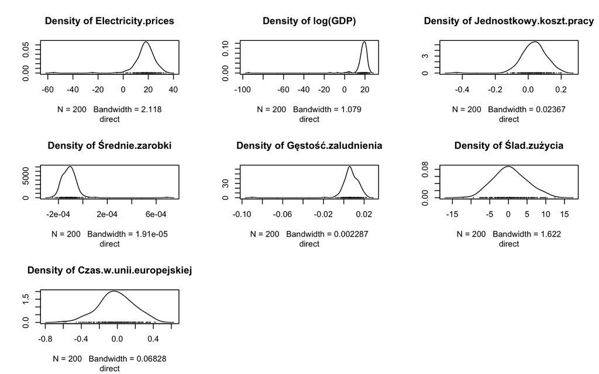

Jednostkowy koszt pracy i gęstość zaludnienia wykazują niewielkie pozytywne wpływy całkowite na PPP. Dla jednostkowego kosztu pracy, efekt bezpośredni (0,0465) jest pozytywny, a efekt pośredni (-0,0221) negatywny, co daje niewielki pozytywny wpływ całkowity w wysokości 0,0244. Podobnie, gęstość zaludnienia ma bezpośredni pozytywny wpływ (0,0088) i pośredni negatywny wpływ (-0,0042), prowadząc do niewielkiego pozytywnego wpływu całkowitego w wysokości 0,0046. Oznacza to, że choć te czynniki lokalnie wspierają poziom cen i siłę nabywczą, to ich wpływ na sąsiadów jest odwrotny.

Ślad zużycia również wykazuje zauważalny pozytywny wpływ całkowity wynoszący 0,4927 na PPP, wynikający z pozytywnego efektu bezpośredniego (0,9405) i negatywnego efektu pośredniego (-0.4478).

Z kolei średnie zarobki i czas w Unii Europejskiej wykazują negatywne wpływy całkowite na PPP. Średnie zarobki mają niewielki negatywny wpływ całkowity wynoszący -0,000063, z negatywnym efektem bezpośrednim (-0,000121) i pozytywnym efektem pośrednim (0,000058). Czas w Unii Europejskiej wykazuje całkowity negatywny wpływ wynoszący -0,0147, wynikający z negatywnego efektu bezpośredniego (-0,0281) i pozytywnego efektu pośredniego (0,0134). Może to sugerować, że dłuższe członkostwo w UE wiąże się z nieco niższym poziomem cen (lub wyższą realną siłą nabywczą), prawdopodobnie z powodu integracji rynkowej i swobodnego przepływu towarów, co może wyrównywać ceny w regionie.

# 6. Podsumowanie

Niniejszy projekt przedstawia analizę czynników kształtujących parytet siły nabywczej (PPP) w krajach Unii Europejskiej w latach 2013-2024, wykorzystując metody ekonometrii przestrzennej. Głównym celem było zidentyfikowanie kluczowych determinantów ekonomicznych wpływających na realny poziom życia i siłę nabywczą walut.

Kluczowym ustaleniem wstępnej fazy badań było stwierdzenie silnej zależności przestrzennej – poziom PPP w danym kraju jest istotnie powiązany z poziomem PPP w krajach sąsiednich. Analiza wykazała istnienie wyraźnych geograficznych klastrów: z jednej strony grupy państw o wysokiej sile nabywczej w Europie Zachodniej i Północnej, a z drugiej – zgrupowania krajów o niższym PPP w Europie Środkowo-Wschodniej. Odkrycie to potwierdziło, że standardowe modele ekonometryczne byłyby niewystarczające, co uzasadniło zastosowanie specjalistycznych technik przestrzennych.

W ramach analizy porównano kilka modeli, w tym klasyczny model regresji oraz modele przestrzenne. Stwierdzono, że standardowy model, pomijający interakcje przestrzenne, prowadził do błędnych wniosków. Na podstawie rygorystycznych kryteriów statystycznych, model z przestrzennym opóźnieniem i efektami stałymi (SAR-FE) został wybrany jako najlepiej dopasowany do danych.

# 7. Bibliografia

Balassa, B. (1964). The Purchasing-Power Parity Doctrine: A Reappraisal. Journal of Political Economy Samuelson, P. A. (1964). Theoretical Notes on Trade Problems. Review of Economics and Statistics Taylor, A. M., & Taylor, M. P. (2004). The Purchasing Power Parity Debate. Journal of Economic Perspectives Gelb, A. & Diofasi, A. (2016). What Determines Purchasing-PowerParity Exchange Rates? Sarno, L. & Taylor, M. P. (2002). Purchasing Power Parity and the Real Exchange Rate. Brueckner, J. K. (2000). Urban sprawl: Diagnosis and remedies. International Regional Science Review.